# **ExtraaLearn Project by Lucky Ejenavi Salomi**

## Project Overview

### Context

The EdTech industry has been surging in the past decade immensely, and according to a forecast, the Online Education market would be worth $286.62bn by 2023 with a compound annual growth rate (CAGR) of 10.26% from 2018 to 2023. The modern era of online education has enforced a lot in its growth and expansion beyond any limit. Due to having many dominant features like ease of information sharing, personalized learning experience, transparency of assessment, etc, it is now preferable to traditional education.

In the present scenario due to the Covid-19, the online education sector has witnessed rapid growth and is attracting a lot of new customers. Due to this rapid growth, many new companies have emerged in this industry. With the availability and ease of use of digital marketing resources, companies can reach out to a wider audience with their offerings. The customers who show interest in these offerings are termed as leads. There are various sources of obtaining leads for Edtech companies, like

- The customer interacts with the marketing front on social media or other online platforms.
- The customer browses the website/app and downloads the brochure
- The customer connects through emails for more information.

The company then nurtures these leads and tries to convert them to paid customers. For this, the representative from the organization connects with the lead on call or through email to share further details.

### Objective

ExtraaLearn is an initial stage startup that offers programs on cutting-edge technologies to students and professionals to help them upskill/reskill. With a large number of leads being generated on a regular basis, one of the issues faced by ExtraaLearn is to identify which of the leads are more likely to convert so that they can allocate resources accordingly. You, as a data scientist at ExtraaLearn, have been provided the leads data to:

- Analyze and build an ML model to help identify which leads are more likely to convert to paid customers,
- Find the factors driving the lead conversion process
- Create a profile of the leads which are likely to convert

### Data Description

The data contains the different attributes of leads and their interaction details with ExtraaLearn. The detailed data dictionary is given below.

**Data Dictionary**

- ID: ID of the lead
- age: Age of the lead
- current_occupation: Current occupation of the lead. Values include 'Professional','Unemployed',and 'Student'
- first_interaction: How did the lead first interacted with ExtraaLearn. Values include 'Website', 'Mobile App'
- profile_completed: What percentage of profile has been filled by the lead on the website/mobile app. Values include Low - (0-50%), Medium - (50-75%), High (75-100%)
- website_visits: How many times has a lead visited the website
- time_spent_on_website: Total time spent on the website
- page_views_per_visit: Average number of pages on the website viewed during the visits.
- last_activity: Last interaction between the lead and ExtraaLearn.
  - Email Activity: Seeking for details about program through email, Representative shared information with lead like brochure of program , etc
  - Phone Activity: Had a Phone Conversation with representative, Had conversation over SMS with representative, etc
  - Website Activity: Interacted on live chat with representative, Updated profile on website, etc
- print_media_type1: Flag indicating whether the lead had seen the ad of ExtraaLearn in the Newspaper.
- print_media_type2: Flag indicating whether the lead had seen the ad of ExtraaLearn in the Magazine.
- digital_media: Flag indicating whether the lead had seen the ad of ExtraaLearn on the digital platforms.
- educational_channels: Flag indicating whether the lead had heard about ExtraaLearn in the education channels like online forums, discussion threads, educational websites, etc.
- referral: Flag indicating whether the lead had heard about ExtraaLearn through reference.
- status: Flag indicating whether the lead was converted to a paid customer or not.

## Importing necessary libraries and data

```python
# Import Numerical Data Analysis and Structured Data Analysis packages
import numpy as np
import pandas as pd

# Data Visualization Packages
import matplotlib.pyplot as plt
import seaborn as sns

# Data Preprocessing - scale the data using z-score
from sklearn.preprocessing import StandardScaler

# Split dataset into train and test
from sklearn.model_selection import train_test_split

# Algorithms to use
from sklearn.tree import DecisionTreeClassifier
from sklearn.ensemble import RandomForestClassifier

# Metrics to evaluate model
from sklearn import metrics
from sklearn.metrics import confusion_matrix, classification_report, \
                        precision_recall_curve, recall_score

# Visualize Decision Tree
from sklearn import tree

# For tuning the model
from sklearn.model_selection import GridSearchCV

# Ignore warnings
import warnings
warnings.filterwarnings("ignore")
```

### Set Themes, Style, etc

```python
# Miscellaneous - Set themes, Styles and options
%matplotlib inline
pd.set_option("display.max_columns", None) #Remove column display limit
sns.set_theme()
```

### Loading the dataset

```python
data = pd.read_csv('ExtraaLearn.csv')
same_data = data.copy(deep=True) # Maintain a deep copy of the dataset
```

```python
data.head()
```

|  | ID | age | current_occupation | first_interaction | profile_completed | website_visits | time_spent_on_website | page_views_per_visit | last_activity | print_media_type1 | print_media_type2 | digital_media | educational_channels | referral | status |
| --- | --- | --- | --- | --- | --- | --- | --- | --- | --- | --- | --- | --- | --- | --- | --- |
| 0 | EXT001 | 57 | Unemployed | Website | High | 7 | 1639 | 1.861 | Website Activity | Yes | No | Yes | No | No | 1 |
| 1 | EXT002 | 56 | Professional | Mobile App | Medium | 2 | 83 | 0.320 | Website Activity | No | No | No | Yes | No | 0 |
| 2 | EXT003 | 52 | Professional | Website | Medium | 3 | 330 | 0.074 | Website Activity | No | No | Yes | No | No | 0 |
| 3 | EXT004 | 53 | Unemployed | Website | High | 4 | 464 | 2.057 | Website Activity | No | No | No | No | No | 1 |
| 4 | EXT005 | 23 | Student | Website | High | 4 | 600 | 16.914 | Email Activity | No | No | No | No | No | 0 |

## Data Overview

- Observations
- Sanity checks

### Data Info

```python
data.info()
```

```
<class 'pandas.core.frame.DataFrame'>
RangeIndex: 4612 entries, 0 to 4611
Data columns (total 15 columns):
 #   Column                 Non-Null Count  Dtype
---  ------                 --------------  -----
 0   ID                     4612 non-null   object
 1   age                    4612 non-null   int64
 2   current_occupation     4612 non-null   object
 3   first_interaction      4612 non-null   object
 4   profile_completed      4612 non-null   object
 5   website_visits         4612 non-null   int64
 6   time_spent_on_website  4612 non-null   int64
 7   page_views_per_visit   4612 non-null   float64
 8   last_activity          4612 non-null   object
 9   print_media_type1      4612 non-null   object
 10  print_media_type2      4612 non-null   object
 11  digital_media          4612 non-null   object
 12  educational_channels   4612 non-null   object
 13  referral               4612 non-null   object
 14  status                 4612 non-null   int64
dtypes: float64(1), int64(4), object(10)
memory usage: 540.6+ KB
```

**Observations**

1. There are **4,612** rows and **15** columns.
2. There are no empty rows or empty columns in the dataset.
3. There are **5** numeric columns (comprising **1** float and **4** integers).
4. Ther are **10** non-numeric/categorical columns.

### Get Column Names

Save column names into variables for reusability throughout the project

```python
[id_
, age
, current_occupation
, first_interaction
, profile_completed
, website_visits
, time_spent_on_website
, page_views_per_visit
, last_activity
, print_media_type1
, print_media_type2
, digital_media
, educational_channels
, referral
, status] = same_data.columns.to_list()
```

### Check for null values in columns

```python
data[data.isnull()].count()
```

```
ID                       0
age                      0
current_occupation       0
first_interaction        0
profile_completed        0
website_visits           0
time_spent_on_website    0
page_views_per_visit     0
last_activity            0
print_media_type1        0
print_media_type2        0
digital_media            0
educational_channels     0
referral                 0
status                   0
dtype: int64
```

**Observations**: There are no empty column(s) in the dataset.

### Check for Duplicate (s)

```python
data.duplicated().sum()
```

```
0
```

**Observations:** There are no duplicated data point in the dataset.

### Check for unique values in columns

```python
data.nunique()
```

```
ID                       4612
age                        46
current_occupation          3
first_interaction           2
profile_completed           3
website_visits             27
time_spent_on_website    1623
page_views_per_visit     2414
last_activity               3
print_media_type1           2
print_media_type2           2
digital_media               2
educational_channels        2
referral                    2
status                      2
dtype: int64
```

**Observation:**

- The ID is an identifier with **4,612** unique values. It adds no value to the data analysis and classification problem. Hence, it should be dropped.

#### Drop Columns not useful for Analysis

```python
columns_drop = [id_]
try:
    data.drop(columns=columns_drop, inplace=True, axis=1)
except KeyError:
    pass
```

## Exploratory Data Analysis (EDA)

- EDA is an important part of any project involving data.
- It is important to investigate and understand the data better before building a model with it.
- A few questions have been mentioned below which will help you approach the analysis in the right manner and generate insights from the data.
- A thorough analysis of the data, in addition to the questions mentioned below, should be done.

**Questions**

1. Leads will have different expectations from the outcome of the course and the current occupation may play a key role in getting them to participate in the program. Find out how current occupation affects lead status.
2. The company's first impression on the customer must have an impact. Do the first channels of interaction have an impact on the lead status?
3. The company uses multiple modes to interact with prospects. Which way of interaction works best?
4. The company gets leads from various channels such as print media, digital media, referrals, etc. Which of these channels have the highest lead conversion rate?
5. People browsing the website or mobile application are generally required to create a profile by sharing their personal data before they can access additional information.Does having more details about a prospect increase the chances of conversion?

#### Split the columns by Types

```python
cat_columns = data.select_dtypes(np.object_).columns.to_list() # categorical columns
num_columns = data.select_dtypes(np.number).columns.to_list() # number columns

# Display the columns
print(f'Categorical Columns: {cat_columns} \n {"-" * 30} \n Numeric Columns: {num_columns}')
```

```
Categorical Columns: ['current_occupation', 'first_interaction', 'profile_completed', 'last_activity', 'print_media_type1', 'print_media_type2', 'digital_media', 'educational_channels', 'referral']
 ------------------------------
 Numeric Columns: ['age', 'website_visits', 'time_spent_on_website', 'page_views_per_visit', 'status']
```

#### Univariate Analysis of Numeric Columns

##### Summary Statistics for Numeric Columns

```python
data[num_columns].describe().T
```

|  | count | mean | std | min | 25% | 50% | 75% | max |
| --- | --- | --- | --- | --- | --- | --- | --- | --- |
| age | 4612.0 | 46.201214 | 13.161454 | 18.0 | 36.00000 | 51.000 | 57.00000 | 63.000 |
| website_visits | 4612.0 | 3.566782 | 2.829134 | 0.0 | 2.00000 | 3.000 | 5.00000 | 30.000 |
| time_spent_on_website | 4612.0 | 724.011275 | 743.828683 | 0.0 | 148.75000 | 376.000 | 1336.75000 | 2537.000 |
| page_views_per_visit | 4612.0 | 3.026126 | 1.968125 | 0.0 | 2.07775 | 2.792 | 3.75625 | 18.434 |
| status | 4612.0 | 0.298569 | 0.457680 | 0.0 | 0.00000 | 0.000 | 1.00000 | 1.000 |

**Observations**

- The average age of leads is ~46 years with the youngest age being 18 years and oldest being 63 years. This indicates diversity of ages. The median age is 51 years. Majority of the leads (75%) are aged between 18 - 57 years. This indicate that majority of the leads are in their active working age. These are people who are likely to show interest in online learning.
- The average website visits is ~4 with maximum being 30. Half of the leads have only visited 3 times. 75% had visited less than or equal 5 times. This indicates that only 25% had visited the website greater than 5 times. This may suggest low activity on the website by a majority of users.
- There is a wide dispersion between the time spent on the websites by different leads. While the minimum is 0, the highest is 2,537.
- There is little variation in the page_views_per_visit as indicated by the standard deviation of ~2. However, 25% of the dataset had views from 4 to 18 than the majority of the leads at 75th percentile with view at just 3.75
- The status column shows that at least 50% of the leads did not lead to paid customers. This is indcative of low lead conversion rate.

##### Visualizing the distribution

```python
# Function to plot a boxplot and a histogram along the same scale

def histogram_boxplot(data, feature, figsize=(12, 7), kde=False, bins=None, color="violet", palette="winter"):
    """
    Boxplot and histogram combined

    data: dataframe
    feature: dataframe column
    figsize: size of figure (default (12,7))
    kde: whether to the show density curve (default False)
    bins: number of bins for histogram (default None)
    """
    f2, (ax_box2, ax_hist2) = plt.subplots(nrows=2, sharex=True,
                                           gridspec_kw={"height_ratios": (0.25, 0.75)},figsize=figsize)

    # show title for the plot with summary statistics
    f2.suptitle(
        f"{str(feature).capitalize()} - \
        Skew:  {data[feature].skew().round(2)} \
        | Mean:  {data[feature].mean().round(2)} \
        | Median:  {data[feature].median()}")

    # Boxplot will be created and a star will indicate the mean value of the column
    sns.boxplot(data=data, x=feature, ax=ax_box2, showmeans=True, color=color)

    # Histogram
    if bins:
        sns.histplot(
        data=data, x=feature, kde=kde, ax=ax_hist2, bins=bins, palette=palette)
    else:
        sns.histplot(data=data, x=feature, kde=kde, ax=ax_hist2)

    # Add mean to the histogram
    ax_hist2.axvline(data[feature].mean(), color="green", linestyle ="--")

    # Add median to the histogram
    ax_hist2.axvline(data[feature].median(), color="black", linestyle="-")
```

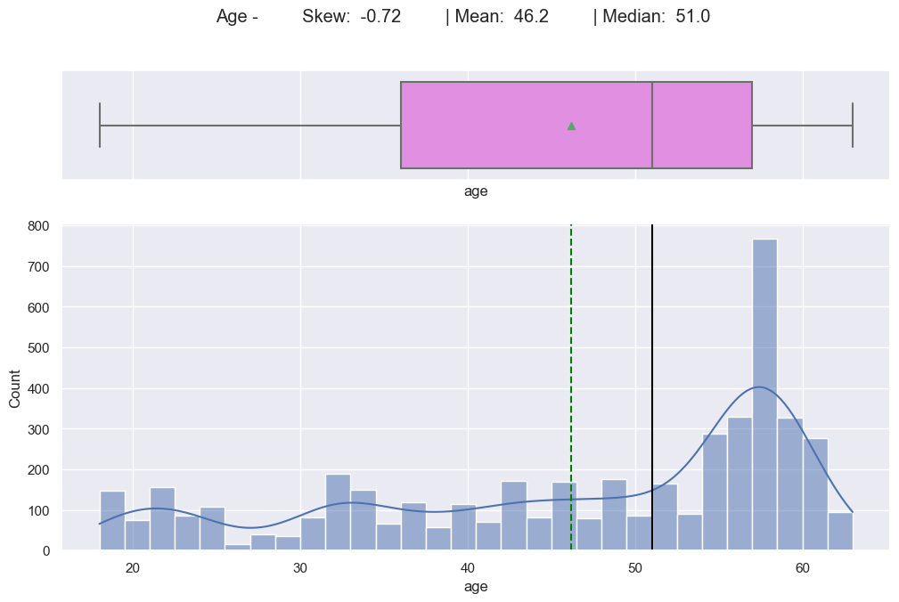

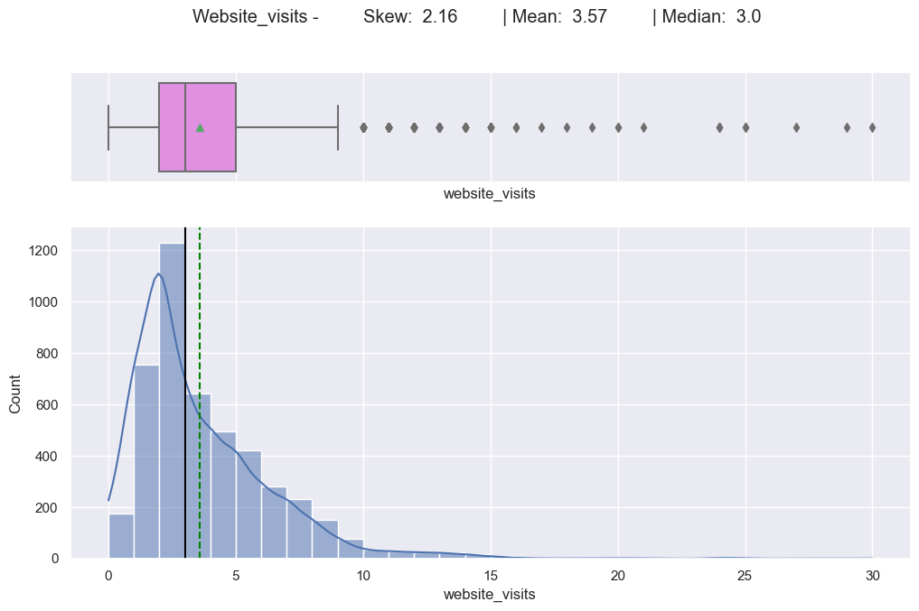

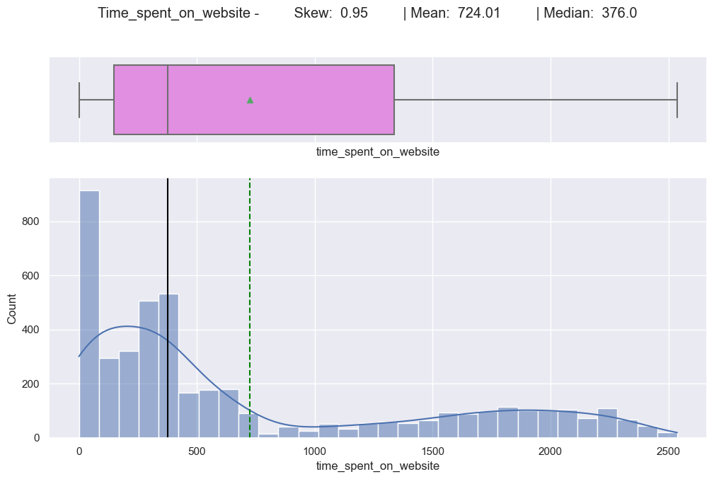

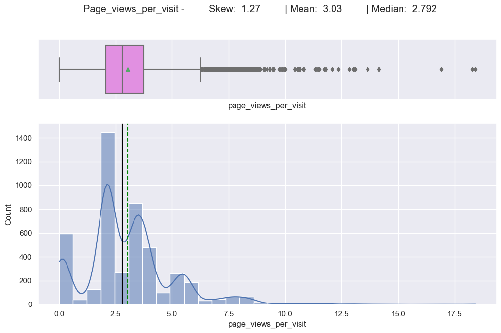

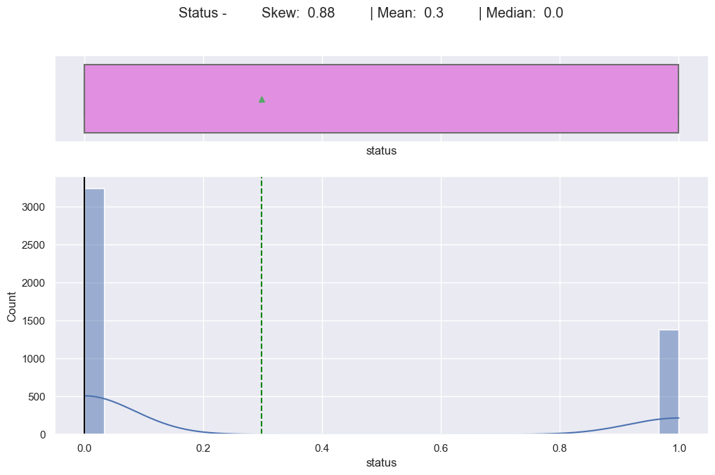

```python
for col in num_columns:
    histogram_boxplot(data, col, kde=True, bins=30)
```

**Observations**

#### Bivariate and Multivariate Analysis of Numeric Columns

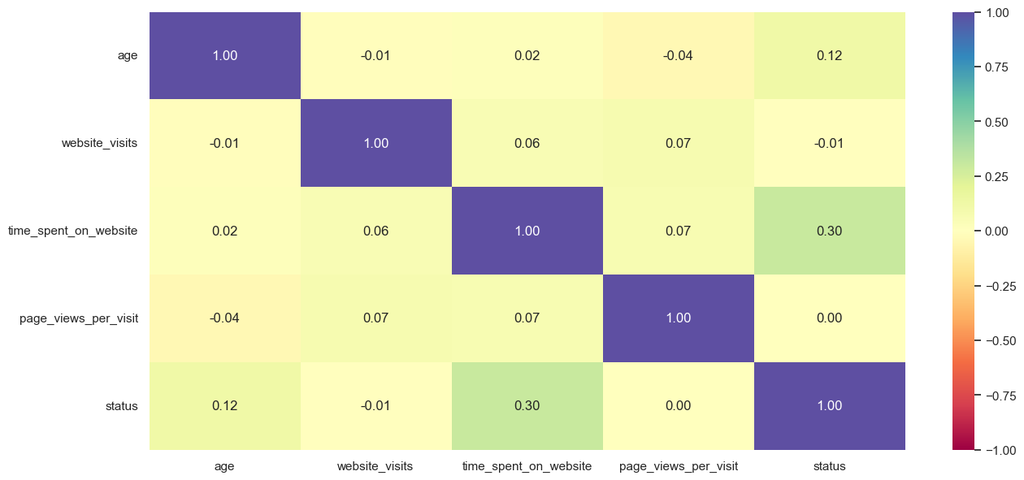

```python
plt.figure(figsize = (15,7))
corr = data[num_columns].corr() # correlation coefficients
sns.heatmap(corr, annot=True, vmin=-1, vmax=1, fmt=".2f", cmap="Spectral");
```

**Observations**

- Only Age and Time spent on website has slight correlations with status at 12% and 30% respectively.
- Other features do not exhibit strong correlation with themselves.
- The above may indicate a combination of factors are required to predict their influence on leads turning to paying customers.
- Categorical variables might be **more important for the prediction**.

#### Univariate Analysis of Categorical Columns

```python
for col in cat_columns:
    print(data[col].value_counts(normalize=True))
    print("-" * 50)
```

```
current_occupation
Professional    0.567216
Unemployed      0.312446
Student         0.120338
Name: proportion, dtype: float64
--------------------------------------------------
first_interaction
Website       0.551171
Mobile App    0.448829
Name: proportion, dtype: float64
--------------------------------------------------
profile_completed
High      0.490893
Medium    0.485906
Low       0.023200
Name: proportion, dtype: float64
--------------------------------------------------
last_activity
Email Activity      0.493929
Phone Activity      0.267563
Website Activity    0.238508
Name: proportion, dtype: float64
--------------------------------------------------
print_media_type1
No     0.892238
Yes    0.107762
Name: proportion, dtype: float64
--------------------------------------------------
print_media_type2
No     0.94948
Yes    0.05052
Name: proportion, dtype: float64
--------------------------------------------------
digital_media
No     0.885733
Yes    0.114267
Name: proportion, dtype: float64
--------------------------------------------------
educational_channels
No     0.847138
Yes    0.152862
Name: proportion, dtype: float64
--------------------------------------------------
referral
No     0.979835
Yes    0.020165
Name: proportion, dtype: float64
--------------------------------------------------
```

**Observations**

- There are more leads who are professionals and that is understandable as the online courses cater mostly for their needs unlike students who follow their school's curriculum. The online course also caters for the unemployed as it offers opportunity to grow their skills in order stand better chance of employment.
- 55% of first interaction with leads take place on the website than mobile app 45%
- There are more people who completed their profiles than those who did not.
- Last contact with the leads show promise as email and phone activity combined equal ~ 75%.
- The leads get acquainted with the online course mostly through other means than from newspaper, magazines, digital media, educational channels and referrals account as they have a combined percentage of ~43% of the dataset.

#### Bivariate Analysis of Categorical Columns

```python
# Function to plot stacked bar plots

def stacked_barplot(data, predictor, target, y_label):
    """
    Print the category counts and plot a stacked bar chart

    data: dataframe
    predictor: independent variable
    target: target variable
    """
    count = data[predictor].nunique()
    sorter = data[target].value_counts().index[-1]
    tab1 = pd.crosstab(data[predictor], data[target], margins = True, normalize='index').sort_values(
        by=sorter, ascending=False)
    print(tab1)
    print("-" * 20)

    # visualize stacked bar chat
    tab = pd.crosstab(data[predictor], data[target], normalize="index").sort_values(
        by=sorter, ascending=False)
    tab.plot(kind="bar", stacked=True, figsize=(count + 1, 5))
    plt.legend(loc="upper left", bbox_to_anchor=(1, 1), frameon=True)
    plt.ylabel(y_label)
    plt.show()
```

```python
# Modified function with default parameters
def stacked_barplot2(predictor):
    stacked_barplot(data, predictor, status, "Lead Conversion Rate (%)")
```

##### Current Occupation

```
status                     0         1
current_occupation
Professional        0.644878  0.355122
All                 0.701431  0.298569
Unemployed          0.734212  0.265788
Student             0.882883  0.117117
--------------------
```

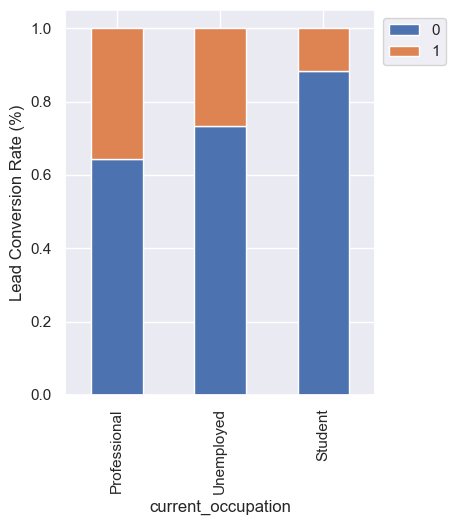

```python
stacked_barplot2(current_occupation)
```

**Observations** Lead conversion rate is highest with professionals at ~35% than any other class.

##### First Interaction

```
status                    0         1
first_interaction
Website            0.544060  0.455940
All                0.701431  0.298569
Mobile App         0.894686  0.105314
--------------------
```

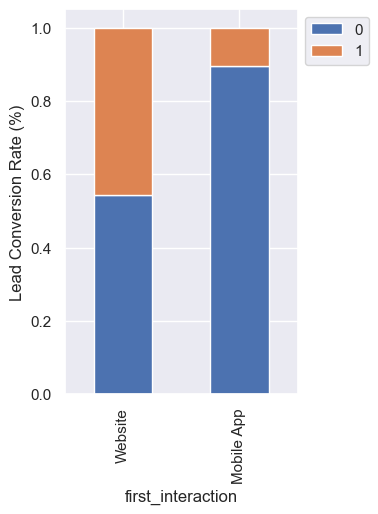

```python
stacked_barplot2(first_interaction)
```

**Observations:** Website first interaction result in significant conversion rate of ~45% than Mobile App at ~10%.

##### Profile Completed

```
status                    0         1
profile_completed
High               0.582155  0.417845
All                0.701431  0.298569
Medium             0.811245  0.188755
Low                0.925234  0.074766
--------------------
```

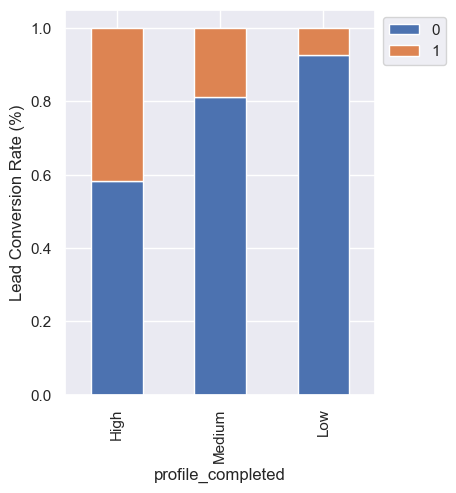

```python
stacked_barplot2(profile_completed)
```

**Observations:** The higher the profile completion rate, the greater the conversion rate. Low profile completion offer the least conversion rate. There is positive correlation between profile completion rate and lead conversion rate.

##### Last Activity

```
status                   0         1
last_activity
Website Activity  0.615455  0.384545
Email Activity    0.696664  0.303336
All               0.701431  0.298569
Phone Activity    0.786872  0.213128
--------------------
```

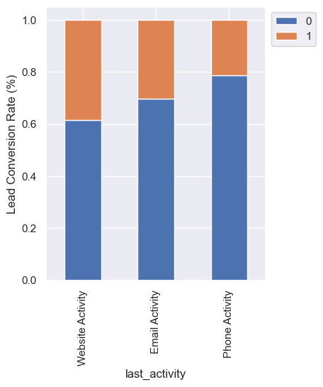

```python
stacked_barplot2(last_activity)
```

**Observations:** Just like first interaction, those with last activity being website tend to convert to paying customers more than those by emails and phone activity. It is not surprising since the online course takes place through the web, web app or a mobile app.

##### Print Media Type 1 - Newspaper

```
status                    0         1
print_media_type1
Yes                0.680080  0.319920
All                0.701431  0.298569
No                 0.704010  0.295990
--------------------
```

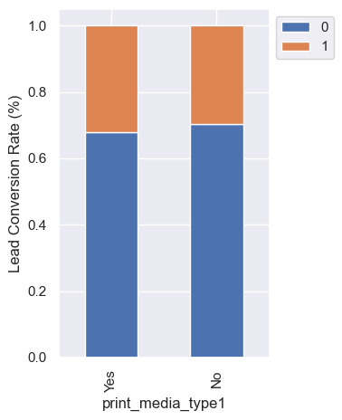

```python
stacked_barplot2(print_media_type1)
```

**Observations:** There is a conversion rate of ~31% for those who got acquainted with the online programme through newspapers. This is low but not surprising as it takes more effort to easily switch from viewing a newspaper to logging to the website.

##### Print Media Type 2 - Magazines

```
status                    0         1
print_media_type2
Yes                0.678112  0.321888
All                0.701431  0.298569
No                 0.702672  0.297328
--------------------
```

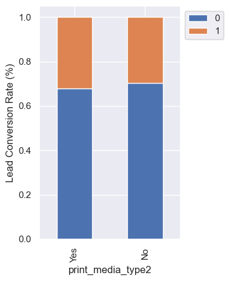

```python
stacked_barplot2(print_media_type2)
```

**Observations:** There is a 32% conversion rate for those who got to know about the online course through magazines. The reason for this is similar to that of newspaper.

##### Digital Media

```
status                0         1
digital_media
Yes            0.681214  0.318786
All            0.701431  0.298569
No             0.704039  0.295961
--------------------
```

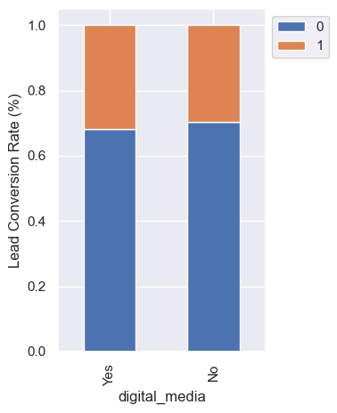

```python
stacked_barplot2(digital_media)
```

**Observations:** There is 31% conversion rate for those who got acquainted with the online course through digital media.

##### Educational Channels

```
status                       0         1
educational_channels
No                    0.697978  0.302022
All                   0.701431  0.298569
Yes                   0.720567  0.279433
--------------------
```

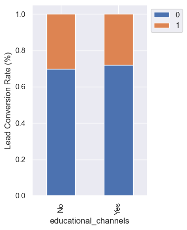

```python
stacked_barplot2(educational_channels)
```

**Observations:** There is ~27% conversion rate for those who got to know about the online course through educational channels.

##### Referrals

```
status           0         1
referral
Yes       0.322581  0.677419
All       0.701431  0.298569
No        0.709228  0.290772
--------------------
```

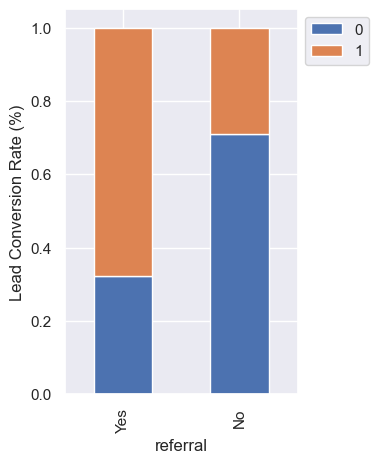

```python
stacked_barplot2(referral)
```

**Observations:**

- There is ~67% conversion rate for leads who were reached through referrals.
- Referrals appears to be a strong determinant of conversion rate among the media outlets.

## Data Preprocessing

- Missing value treatment (if needed)
- Feature engineering (if needed)
- Outlier detection and treatment (if needed)
- Preparing data for modeling
- Any other preprocessing steps (if needed)

### Encoding of categorical variables

```python
try:
    data = pd.get_dummies(data=data, columns=cat_columns, dtype=np.int64, drop_first=True)
except KeyError:
    pass

data.head()
```

|  | age | website_visits | time_spent_on_website | page_views_per_visit | status | current_occupation_Student | current_occupation_Unemployed | first_interaction_Website | profile_completed_Low | profile_completed_Medium | last_activity_Phone Activity | last_activity_Website Activity | print_media_type1_Yes | print_media_type2_Yes | digital_media_Yes | educational_channels_Yes | referral_Yes |
| --- | --- | --- | --- | --- | --- | --- | --- | --- | --- | --- | --- | --- | --- | --- | --- | --- | --- |
| 0 | 57 | 7 | 1639 | 1.861 | 1 | 0 | 1 | 1 | 0 | 0 | 0 | 1 | 1 | 0 | 1 | 0 | 0 |
| 1 | 56 | 2 | 83 | 0.320 | 0 | 0 | 0 | 0 | 0 | 1 | 0 | 1 | 0 | 0 | 0 | 1 | 0 |
| 2 | 52 | 3 | 330 | 0.074 | 0 | 0 | 0 | 1 | 0 | 1 | 0 | 1 | 0 | 0 | 1 | 0 | 0 |
| 3 | 53 | 4 | 464 | 2.057 | 1 | 0 | 1 | 1 | 0 | 0 | 0 | 1 | 0 | 0 | 0 | 0 | 0 |
| 4 | 23 | 4 | 600 | 16.914 | 0 | 1 | 0 | 1 | 0 | 0 | 0 | 0 | 0 | 0 | 0 | 0 | 0 |

### Seperating the independent variables (x) and the dependent (target) variable (y)

```python
y = data[status]
x = data.drop(columns=[status])
```

### Splitting of data into train and test

**Splitting the data into 70% train and 30% test set**

Some classification problems can exhibit a large imbalance in the distribution of the target classes: for instance there could be several times more negative samples than positive samples. In such cases it is recommended to use the stratified sampling technique to ensure that relative class frequencies are approximately preserved in each train and validation fold.

```python
test_size = 0.3
random_state = 1

# call the train_test_split function on the dataset
x_train, x_test, y_train, y_test = \
            train_test_split(x, y, test_size=test_size, shuffle=True, stratify=y, random_state=random_state)
```

## EDA

- It is a good idea to explore the data once again after manipulating it.

```python
x.info() # get info on the predictors after encoding the categorical variables
```

```
<class 'pandas.core.frame.DataFrame'>
RangeIndex: 4612 entries, 0 to 4611
Data columns (total 16 columns):
 #   Column                          Non-Null Count  Dtype
---  ------                          --------------  -----
 0   age                             4612 non-null   int64
 1   website_visits                  4612 non-null   int64
 2   time_spent_on_website           4612 non-null   int64
 3   page_views_per_visit            4612 non-null   float64
 4   current_occupation_Student      4612 non-null   int64
 5   current_occupation_Unemployed   4612 non-null   int64
 6   first_interaction_Website       4612 non-null   int64
 7   profile_completed_Low           4612 non-null   int64
 8   profile_completed_Medium        4612 non-null   int64
 9   last_activity_Phone Activity    4612 non-null   int64
 10  last_activity_Website Activity  4612 non-null   int64
 11  print_media_type1_Yes           4612 non-null   int64
 12  print_media_type2_Yes           4612 non-null   int64
 13  digital_media_Yes               4612 non-null   int64
 14  educational_channels_Yes        4612 non-null   int64
 15  referral_Yes                    4612 non-null   int64
dtypes: float64(1), int64(15)
memory usage: 576.6 KB
```

```python
y.info() # get info on the target
```

```
<class 'pandas.core.series.Series'>
RangeIndex: 4612 entries, 0 to 4611
Series name: status
Non-Null Count  Dtype
--------------  -----
4612 non-null   int64
dtypes: int64(1)
memory usage: 36.2 KB
```

```python
x_train.info() # get info on the predictors train dataset
```

```
<class 'pandas.core.frame.DataFrame'>
Index: 3228 entries, 389 to 2455
Data columns (total 16 columns):
 #   Column                          Non-Null Count  Dtype
---  ------                          --------------  -----
 0   age                             3228 non-null   int64
 1   website_visits                  3228 non-null   int64
 2   time_spent_on_website           3228 non-null   int64
 3   page_views_per_visit            3228 non-null   float64
 4   current_occupation_Student      3228 non-null   int64
 5   current_occupation_Unemployed   3228 non-null   int64
 6   first_interaction_Website       3228 non-null   int64
 7   profile_completed_Low           3228 non-null   int64
 8   profile_completed_Medium        3228 non-null   int64
 9   last_activity_Phone Activity    3228 non-null   int64
 10  last_activity_Website Activity  3228 non-null   int64
 11  print_media_type1_Yes           3228 non-null   int64
 12  print_media_type2_Yes           3228 non-null   int64
 13  digital_media_Yes               3228 non-null   int64
 14  educational_channels_Yes        3228 non-null   int64
 15  referral_Yes                    3228 non-null   int64
dtypes: float64(1), int64(15)
memory usage: 428.7 KB
```

```python
y_train.info() # get info on the target train dataset
```

```
<class 'pandas.core.series.Series'>
Index: 3228 entries, 389 to 2455
Series name: status
Non-Null Count  Dtype
--------------  -----
3228 non-null   int64
dtypes: int64(1)
memory usage: 50.4 KB
```

```python
x_test.info()
```

```
<class 'pandas.core.frame.DataFrame'>
Index: 1384 entries, 2362 to 1810
Data columns (total 16 columns):
 #   Column                          Non-Null Count  Dtype
---  ------                          --------------  -----
 0   age                             1384 non-null   int64
 1   website_visits                  1384 non-null   int64
 2   time_spent_on_website           1384 non-null   int64
 3   page_views_per_visit            1384 non-null   float64
 4   current_occupation_Student      1384 non-null   int64
 5   current_occupation_Unemployed   1384 non-null   int64
 6   first_interaction_Website       1384 non-null   int64
 7   profile_completed_Low           1384 non-null   int64
 8   profile_completed_Medium        1384 non-null   int64
 9   last_activity_Phone Activity    1384 non-null   int64
 10  last_activity_Website Activity  1384 non-null   int64
 11  print_media_type1_Yes           1384 non-null   int64
 12  print_media_type2_Yes           1384 non-null   int64
 13  digital_media_Yes               1384 non-null   int64
 14  educational_channels_Yes        1384 non-null   int64
 15  referral_Yes                    1384 non-null   int64
dtypes: float64(1), int64(15)
memory usage: 183.8 KB
```

```python
y_test.info()
```

```
<class 'pandas.core.series.Series'>
Index: 1384 entries, 2362 to 1810
Series name: status
Non-Null Count  Dtype
--------------  -----
1384 non-null   int64
dtypes: int64(1)
memory usage: 21.6 KB
```

**Observations**

- The categorical variables have been encoded.
- The dataset has been split into train and test data in the ratio 70:30

## Model Building

- Decision Tree gives more significance to the dominant class based on weightage. Hence, we need to pass a dictionary of the hyperparameter class_weight to the Decision Tree Class in order to take account of this.

```python
# Get the weight of each class
wt_class_0 = np.round(data[data[status]==0].shape[0]/data.shape[0], 2) # Weight of class 0
wt_class_1 = np.round(1 - wt_class_0, 2) # Weight of class 1

class_weight = {0:wt_class_0, 1:wt_class_1}
print(class_weight)
```

```
{0: 0.7, 1: 0.3}
```

### Model Evaluation

#### Model Evaluation Criterion

**The model can make two types of wrong predictions:**

1. Predicting that a lead will convert to a paying customer when it does not - **False Positive (FP).**
2. Predicting that a lead will not convert to a paying customer when it actually does - **False Negative (FN).**

**Which case is more important?**

#### Model Evaluation Function for all Models

```python
# Model Evaluation Function to avoid repeating the code
def metrics_score(actual, predicted):
    print("Classification Report")
    print(classification_report(actual, predicted))

    cm = confusion_matrix(actual, predicted)
    plt.figure(figsize=(8,5))

    classes = ['Not Convert (-)', 'Convert (+)']
    plt.title("Confusion Matrix")
    sns.heatmap(cm, annot=True,  fmt='.2f', xticklabels=classes, yticklabels=classes)
    plt.ylabel('Actual')
    plt.xlabel('Predicted')
    plt.show()
```

#### Function to view feature importance

```python
# Re-usable function for viewing important features
def plot_importance(model):
    f_importances = model.feature_importances_
    columns = x.columns

    col_importance = "importance" # name of `importance` column
    col_cum_importance = 'cum_importance' # name of `cumulative importance` column

    df_importance = pd.DataFrame(
        data=f_importances, index=columns, columns=[col_importance]).sort_values(by=col_importance, \
                                                                               ascending=False)
    df_importance[col_cum_importance] = df_importance[col_importance].cumsum() # Add cummulative importance
    print(df_importance)
    print('-' * 50)
    plt.figure(figsize=(12, 7))
    sns.barplot(x=df_importance[col_importance], y=df_importance.index);
```

### Building a Decision Tree model

- Decision Tree gives more significance to the dominant class based on weightage. Hence, we need to pass a dictionary of the hyperparameter class_weight to the Decision Tree Class in order to take account of this.

```python
# Building the Decision Tree model
dt = DecisionTreeClassifier(class_weight=class_weight, random_state=random_state)
dt
```

```
DecisionTreeClassifier(class_weight={0: 0.7, 1: 0.3}, random_state=1)
```

```python
# Fitting the decision tree model
dt.fit(x_train, y_train)
```

```
DecisionTreeClassifier(class_weight={0: 0.7, 1: 0.3}, random_state=1)
```

#### Evaluating the Decision Model Tree Model

```
Classification Report
              precision    recall  f1-score   support

           0       1.00      1.00      1.00      2264
           1       1.00      1.00      1.00       964

    accuracy                           1.00      3228
   macro avg       1.00      1.00      1.00      3228
weighted avg       1.00      1.00      1.00      3228
```

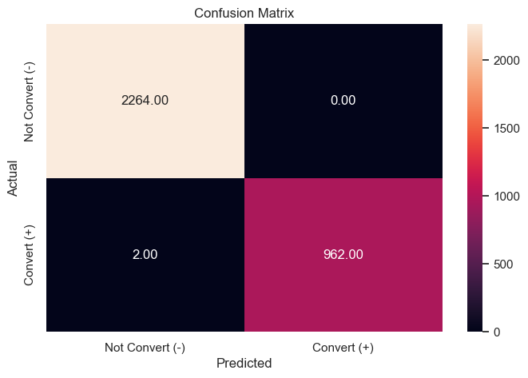

```python
# checking the performance against training dataset
y_train_predict_dt = dt.predict(x_train) # Get Decision Tree Model predicted values
metrics_score(y_train, y_train_predict_dt) #call function for metrics evaluation
```

**Observations:**

- The Decision Tree is giving **100% for all evaluation metrics on the training data**.

```
Classification Report
              precision    recall  f1-score   support

           0       0.86      0.85      0.85       971
           1       0.65      0.68      0.67       413

    accuracy                           0.80      1384
   macro avg       0.76      0.76      0.76      1384
weighted avg       0.80      0.80      0.80      1384
```

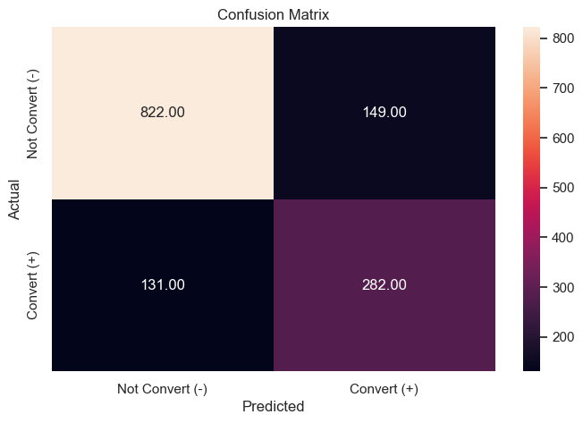

```python
# checking the performance of the model on test data
y_test_predict_dt = dt.predict(x_test) # Get Decision Tree Model predicted values
metrics_score(y_test, y_test_predict_dt)  #call function for metrics evaluation
```

**Observations:**

- The Decision Tree works well on training data but **not so well on the test data** as the recall rate is 68% on Class 1 in comparison to 100% for the training data, i.e, the Decision Tree is overfitting on the training data.
- The precison of 65% suggests that there is a 35% chance that the model will predict that a prospect will convert to a paying customer when it does not and **the company may waste time and resources chasing after a prospects that may not show interest in converting.**

#### Let's check the feature importance of the Decision Tree

```
                                importance  cum_importance
time_spent_on_website             0.270852        0.270852
age                               0.150092        0.420943
page_views_per_visit              0.141078        0.562022
first_interaction_Website         0.089354        0.651376
profile_completed_Medium          0.088326        0.739702
current_occupation_Unemployed     0.060075        0.799777
last_activity_Phone Activity      0.055938        0.855715
website_visits                    0.048466        0.904181
last_activity_Website Activity    0.025233        0.929414
profile_completed_Low             0.023511        0.952925
print_media_type1_Yes             0.013465        0.966390
digital_media_Yes                 0.009467        0.975857
print_media_type2_Yes             0.008284        0.984141
educational_channels_Yes          0.008193        0.992335
referral_Yes                      0.007665        1.000000
current_occupation_Student        0.000000        1.000000
--------------------------------------------------
```

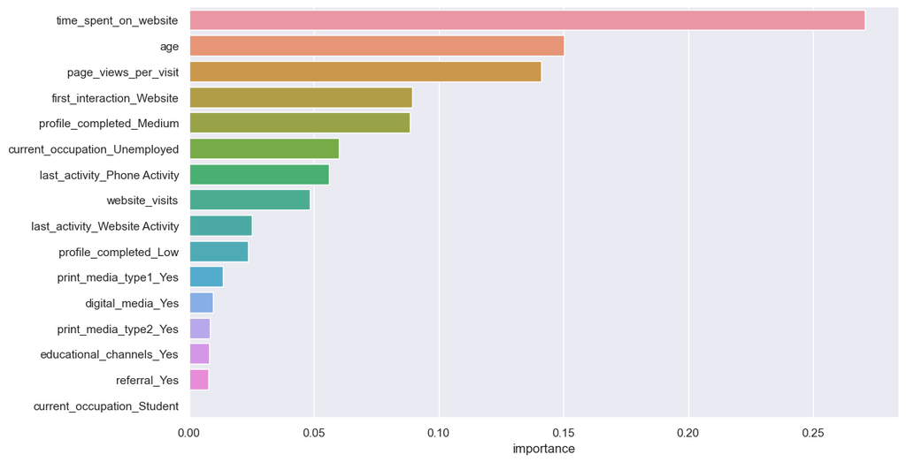

```python
# Plot the importance features for the Decision Tree
plot_importance(dt)
```

**Observations:**

- According to the Decision Tree Model, **time spent on the website** is the most important feature.
- Other important features are: `Page Views Per Visit`, `First Interaction-Website` and `Profile Completed-Medium`.
- `Time Spent on Website`, `Age, Page Views Per Visit`, `First Interaction-Website` and `Profile Completed-Medium` account for **more than 70% importance.**
- This might signify that a prospect with significant time spent the website, together with the total page views per visit, first interaction being website and medium completed profile (50-75%) are more than likely to convert to paying customers.
- The least important features are the referral channel and students.

**Visualize the Tree**

```python
# Re-usable function to visualize Decision Tree
def visualise_dt(dt_class):
    features = list(x.columns)
    max_depth = 3
    class_names = ['NC', 'C'] # NC - Not Convert, C - Convert

    regressor_visualize = dt_class(
                class_weight=class_weight, random_state=1, max_depth=max_depth) # instantiate the DT object
    regressor_visualize.fit(x_train, y_train) #fit the DT

    plt.figure(figsize=(30, 20))

    #Plot the DT
    tree.plot_tree(regressor_visualize, max_depth=max_depth,
               feature_names=features, filled=True, class_names=class_names, node_ids=True, fontsize=12);
```

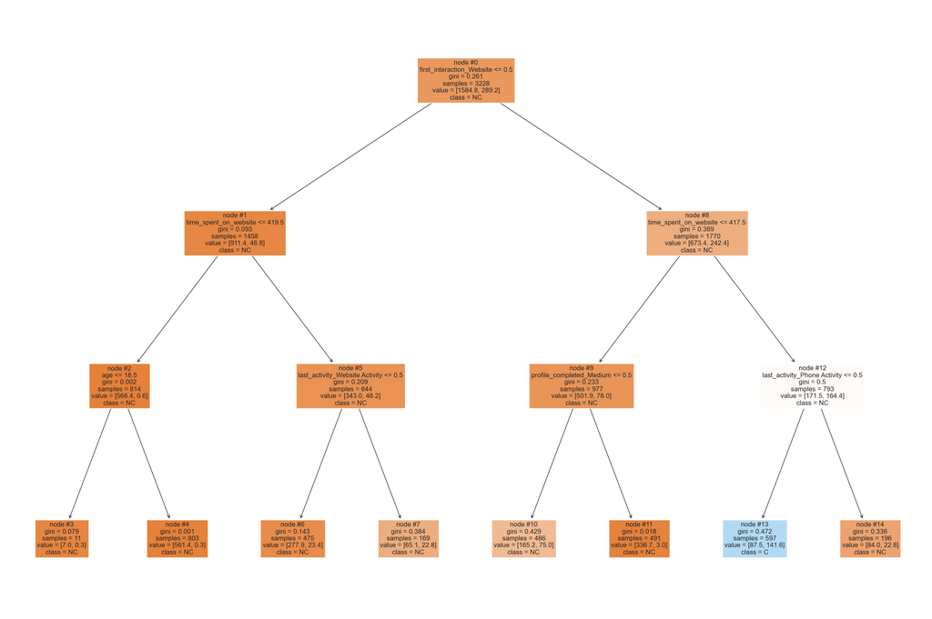

```python
# Visualize the Decision Tree
visualise_dt(DecisionTreeClassifier)
```

**Observations:**

#### Do we need to prune the tree?

A Decision tree that is trained to its full depth will highly likely lead to overfitting the training data - therefore Pruning is important. In simpler terms, the aim of Decision Tree Pruning is to construct an algorithm that will generalize better on test data.

**The tree needs pruning because it overfits on the training data and unable to generalize on the test data.

```python
# Tuning of the Decision Tree
dt_tuned_classifier = DecisionTreeClassifier(random_state=random_state) #Tuned Object of the Decision Tree

# Grid of parameters to choose from
df_parameters = {
    "max_depth": [5, 7, None],
    "max_features": [None, 0.8, 1],
    "random_state": [None, random_state, 0],
    "class_weight": [None, class_weight, {0: wt_class_1, 1: wt_class_0}]
             }

# Run the grid search
dt_grid_obj = GridSearchCV(dt_tuned_classifier, df_parameters, scoring='neg_mean_squared_error', cv=5)

dt_grid_obj = dt_grid_obj.fit(x_train, y_train)

# Set the dt_tuned_classifier to the best combination of parameters
dt_tuned_classifier = dt_grid_obj.best_estimator_

dt_tuned_classifier.fit(x_train, y_train)
```

```
DecisionTreeClassifier(max_depth=7, max_features=0.8)
```

```
Classification Report
              precision    recall  f1-score   support

           0       0.92      0.93      0.92      2264
           1       0.82      0.80      0.81       964

    accuracy                           0.89      3228
   macro avg       0.87      0.86      0.87      3228
weighted avg       0.89      0.89      0.89      3228
```

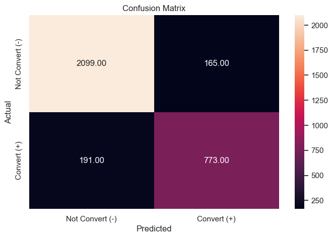

```python
# test the tuned Decision Tree on training data
y_dt_tuned_pred_train = dt_tuned_classifier.predict(x_train)
metrics_score(y_train, y_dt_tuned_pred_train)
```

**Observations:**

- Overfitting of the model on the training data seems to be better post-tuning.

```
Classification Report
              precision    recall  f1-score   support

           0       0.89      0.91      0.90       971
           1       0.78      0.73      0.76       413

    accuracy                           0.86      1384
   macro avg       0.84      0.82      0.83      1384
weighted avg       0.86      0.86      0.86      1384
```

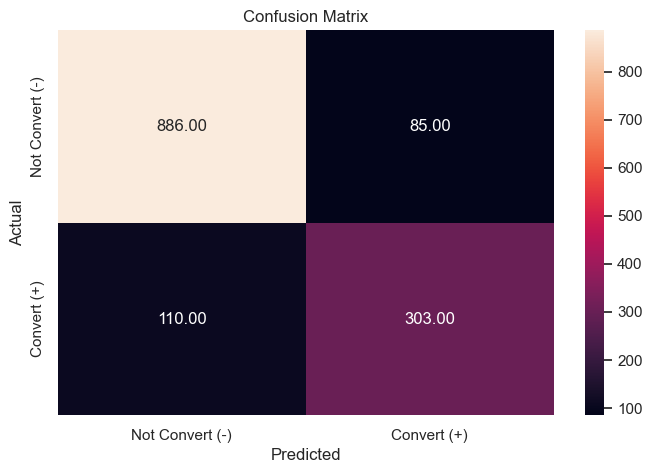

```python
# evaluate the performance of the Tuned Decison Tree on Test Data
y_dt_tuned_pred = dt_tuned_classifier.predict(x_test)
metrics_score(y_test, y_dt_tuned_pred)
```

**Observations:**

#### Check Feature Importance After Tuning the Decision Tree

```
                                importance  cum_importance
time_spent_on_website             0.267061        0.267061
first_interaction_Website         0.233041        0.500102
profile_completed_Medium          0.188034        0.688136
current_occupation_Unemployed     0.058987        0.747123
last_activity_Phone Activity      0.049070        0.796194
age                               0.043749        0.839943
last_activity_Website Activity    0.040387        0.880330
current_occupation_Student        0.037550        0.917880
page_views_per_visit              0.035666        0.953546
profile_completed_Low             0.023198        0.976744
website_visits                    0.008851        0.985595
print_media_type1_Yes             0.005520        0.991115
referral_Yes                      0.005289        0.996404
digital_media_Yes                 0.003596        1.000000
print_media_type2_Yes             0.000000        1.000000
educational_channels_Yes          0.000000        1.000000
--------------------------------------------------
```

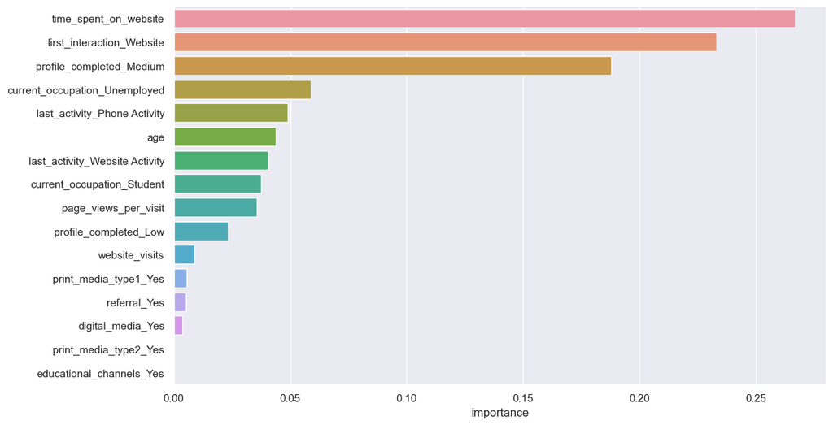

```python
plot_importance(dt_tuned_classifier)
```

**Observations:**

### Building a Random Forest Model

- **Random Forest is a bagging algorithm where the base models are Decision Trees.** Samples are taken from the training data and on each sample, a decision tree makes a prediction.
- The results from all the **decision trees** are combined and the final prediction is made using **voting** (for classification problems) or **averaging** (for regression problems).**

#### Random Forest Model

```python
# Fitting the Random Forest classifier on the training dataset
rf_estimator = RandomForestClassifier(class_weight=class_weight, random_state=random_state)
rf_estimator.fit(x_train, y_train)
```

```
RandomForestClassifier(class_weight={0: 0.7, 1: 0.3}, random_state=1)
```

#### Evaluate the Random Forest Model

```
Classification Report
              precision    recall  f1-score   support

           0       1.00      1.00      1.00      2264
           1       1.00      1.00      1.00       964

    accuracy                           1.00      3228
   macro avg       1.00      1.00      1.00      3228
weighted avg       1.00      1.00      1.00      3228
```

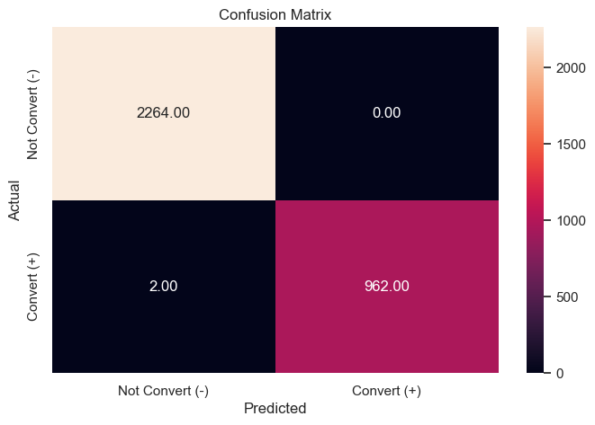

```python
# Checking the performance of the model on training data
rf_pred_train = rf_estimator.predict(x_train)

metrics_score(y_train, rf_pred_train)
```

**Observations:**

- For all the metrics, the Random Forest Predictor gives a **100% score**.

```
Classification Report
              precision    recall  f1-score   support

           0       0.89      0.91      0.90       971
           1       0.77      0.73      0.75       413

    accuracy                           0.85      1384
   macro avg       0.83      0.82      0.82      1384
weighted avg       0.85      0.85      0.85      1384
```

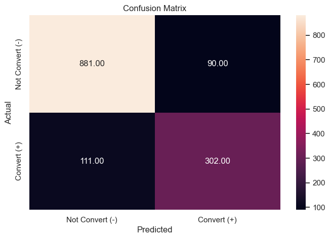

```python
# Test the performance of the Random Forest predictor on test data
rf_pred_test = rf_estimator.predict(x_test)
metrics_score(y_test, rf_pred_test)
```

**Observations:**

- The Random Forest predictor has a **Class 1 Recall of 73%** on test data. This is lower than the 100% on training data, indicating an overfitting.
- Class 1 Precision of 77% is low for the test data as well. This indicates that there is 23% chance that a lead will not convert to paying customer when the predictor suggest so.
- However, the Random Forest predictor with **Class 1 Recall/Precison of 73%/77%** shows better promise than the base Decision Tree with **Class 1 Recall/Precision rate of 68%/65%**.

#### Let's check the feature importance of RF

```
                                importance  cum_importance
time_spent_on_website             0.247958        0.247958
first_interaction_Website         0.144227        0.392184
page_views_per_visit              0.141501        0.533686
age                               0.122586        0.656271
website_visits                    0.072276        0.728548
profile_completed_Medium          0.071696        0.800243
current_occupation_Unemployed     0.041202        0.841445
last_activity_Phone Activity      0.040113        0.881558
last_activity_Website Activity    0.026710        0.908267
current_occupation_Student        0.016074        0.924341
educational_channels_Yes          0.015642        0.939983
profile_completed_Low             0.014487        0.954470
print_media_type1_Yes             0.014081        0.968551
digital_media_Yes                 0.012836        0.981387
referral_Yes                      0.010009        0.991396
print_media_type2_Yes             0.008604        1.000000
--------------------------------------------------
```

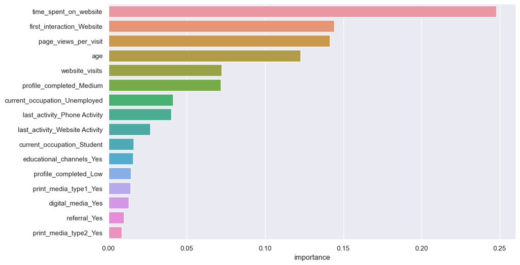

```python
plot_importance(rf_estimator)
```

**Observations:**

- The Random Forest model further lend credence to the fact that Time Spent on website, page views per visit, first interaction - website, website visits, profile completed rate are all critical to determining the lead conversion rate.
- Prospects who had first interaction with the online course through website, spend more time on the website, with actual activities evidenced by page views per visit and profile completion rate will most likely stand better chance of being converted to paying customers.
- Other features like employment status, last activity by phone are also important. Those who are unemployed stand better conversion rate than students as they seek to upskill for the next interview.

#### Do we need to prune the tree?

The Random Forest estimator performs poorly on the test data due to overfitting. The tree will need to be pruned to obtain better results. This guarantees that the predictor will perform better on unseen data.

```python
rf_tuned_class = RandomForestClassifier(random_state = random_state)

# Grid of parameters to choose from
rf_parameters = {
    "n_estimators": [100, 110, 120],
    "max_depth": [5, 7, None],
    "max_features": [0.8, 1],
    "random_state": [None, random_state, 0],
    "class_weight": [None, class_weight, {0: wt_class_1, 1: wt_class_0}]
             }

# Run the grid search
rf_grid_obj = GridSearchCV(rf_tuned_class, rf_parameters, scoring='neg_mean_squared_error', cv=5)

rf_grid_obj = rf_grid_obj.fit(x_train, y_train)

# Set the rf_tuned_classifier to the best combination of parameters
rf_tuned_class = rf_grid_obj.best_estimator_

rf_tuned_class.fit(x_train, y_train)
```

```
RandomForestClassifier(max_depth=7, max_features=0.8, n_estimators=120,
                       random_state=1)
```

```
Classification Report
              precision    recall  f1-score   support

           0       0.92      0.94      0.93      2264
           1       0.84      0.82      0.83       964

    accuracy                           0.90      3228
   macro avg       0.88      0.88      0.88      3228
weighted avg       0.90      0.90      0.90      3228
```

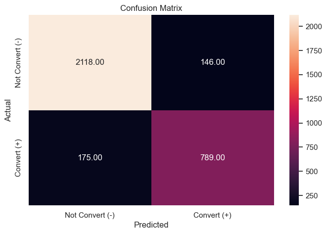

```python
# checking the performance against training dataset
y_train_predict_rf_tuned = rf_tuned_class.predict(x_train)
metrics_score(y_train, y_train_predict_rf_tuned)
```

```
Classification Report
              precision    recall  f1-score   support

           0       0.90      0.92      0.91       971
           1       0.79      0.75      0.77       413

    accuracy                           0.87      1384
   macro avg       0.84      0.83      0.84      1384
weighted avg       0.87      0.87      0.87      1384
```

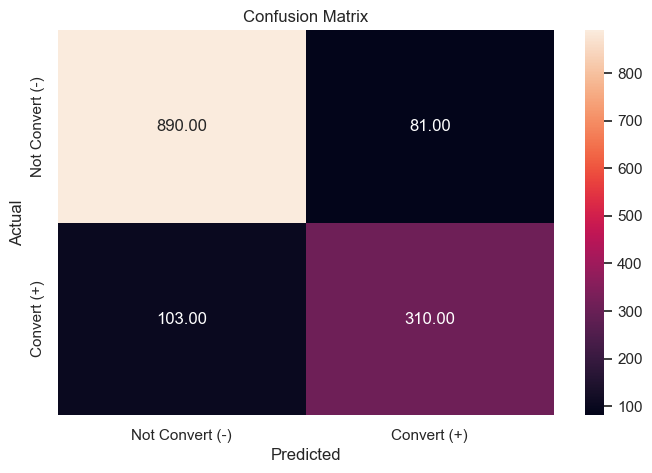

```python
# checking the performance against testing dataset
y_test_predict_rf_tuned = rf_tuned_class.predict(x_test)
metrics_score(y_test, y_test_predict_rf_tuned)
```

**Observations:**

#### View the Final Feature Importance

```
                                importance  cum_importance
time_spent_on_website             0.263980        0.263980
first_interaction_Website         0.245381        0.509361
profile_completed_Medium          0.152576        0.661938
age                               0.070182        0.732120
last_activity_Phone Activity      0.055938        0.788058
current_occupation_Unemployed     0.047069        0.835126
page_views_per_visit              0.045013        0.880139
last_activity_Website Activity    0.033564        0.913703
website_visits                    0.023975        0.937678
profile_completed_Low             0.023008        0.960686
current_occupation_Student        0.021352        0.982038
referral_Yes                      0.006585        0.988624
educational_channels_Yes          0.003973        0.992596
print_media_type1_Yes             0.003472        0.996069
digital_media_Yes                 0.002665        0.998734
print_media_type2_Yes             0.001266        1.000000
--------------------------------------------------
```

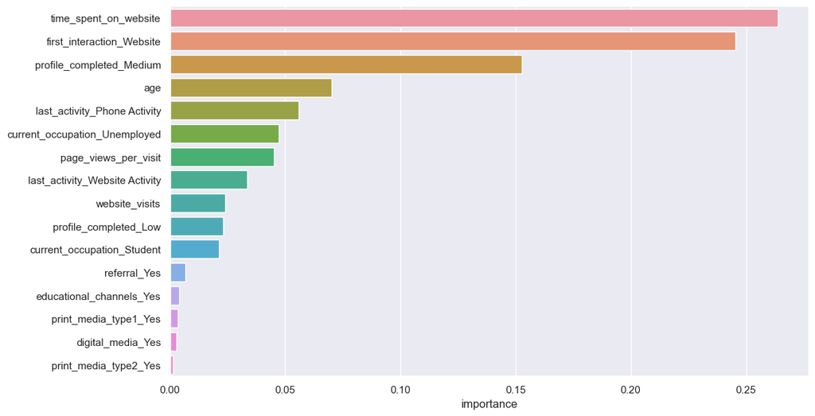

```python
plot_importance(rf_tuned_class)
```

**Observations:**

- The feature importance has not changed much from the previous trained models

## Actionable Insights and Recommendations

### Insights

1. The greatest factor to consider in order to improve lead conversion rate is **Time Spent on Website** by potential customers.
2. Applying the Pareto 80/20 principle, factors which offers the greatest potential at converting leads to paying customers are: `Time Spent on website`, `first interaction - website`, `profile completion rate - medium`, `age`, `last activity by phone` and the `unemployed`.
3. `Time Spent on website`, `first interaction - website` account for more than 50% in terms of importance.
4. The media platforms have not added much significance to lead conversion rate. This can be boosted.

### Recommendations

- The company should follow up with leads who have spent much time on the website. This should go with the page views per visit in order to filter out those may just be idling on the website without actually viewing.
- The first channel should have maximum impact on the customers. Special attention should be paid to the website, its interface, attraction and appeal to the customers.
- The company should utilize more Search Engine Optimization (SEO) in order to drive more people to have their first interaction with the online course through the web.
- Potential customers who have not considerably filled their profile greater than 50% should be followed up.
- Potential customers who are unemployed and have spent much time on the website should be followed up and probably offered personalized discount due to their reduced ability to pay. They are likely to show more interest in online course in order to upskill for their next job.
- The media channels are not adding much in terms of conversion rate. They should be investigated and re-energized for better penetration. One are of media that easily scale is the digital media.
- The company should encourage referral in order to boost enrolment. Potential customers tend to trust words from their friends, family or acquaintances more. The referral programme could be incentivitized to encourage more of it.